# Set up an hvtiR study for descriptive and EDA work

John Ehrlinger

Source: [`vignettes/study-setup.qmd`](https://github.com/ehrlinger/hvtiRtemplates/blob/main/vignettes/study-setup.qmd)

This is the common first tutorial for an hvtiR study. Start on one of two paths:

1. create a study that has no files yet; or
2. adopt an existing study without rewriting its working directories.

Both paths meet at the same study contract. From there, register the data, write an `eda` analysis set, and create the five jobs used before a specific analysis begins: general checks, descriptive tables, goodness of follow-up, trends, and EDA postage stamps.

The executable example builds both paths from 40 synthetic observations and a named 24-row subset. Every file stays in a temporary directory. During rendering, that directory is removed after the R chunks run; the displayed figure is embedded before cleanup. Run the chunks in order in one interactive session to inspect the files yourself. For the statistical mapping behind the jobs, see From SAS descriptive jobs to R.

The render steps require Quarto and the packages declared by the job templates, including `hvtiRdatabuild >= 0.2.1`, `hvtiRtables >= 1.0.1`, and `hvtiPlotR >= 2.7.14`. A missing or older dependency stops the render and names the required version.

### Path A: create a new study

A new study begins at a path that does not exist. `study_setup()` creates the numbered working directories, `_study.yml`, an R project, `.Renviron`, and `.renvignore`. Use the study’s real Study Tracker ID and title.

```r
study_setup(
  new_root,
  study = "Synthetic new study",
  study_tracker_id = 43L
)
```

```
#> Study: /tmp/RtmpK1toKf/file1d653b6086fe/new-study
#>
#> [x] _study.yml — study: Synthetic new study
#> [ ] renv.lock — no renv.lock; run renv::init() in the study project
#> [ ] manifest.yaml — no manifest.yaml; register_data() creates it
#> [ ] dataset — no default dataset registered; run register_data()
#> [ ] cohort — requires a registered default dataset
#> [ ] provenance — no .qmd/.Rmd sources found; 0 sidecars
#>
#> 0 .R  |  0 .qmd/.Rmd  |  0 .sas  |  0 provenance sidecars
```

```r
list.dirs(new_root, recursive = FALSE, full.names = FALSE)
```

```
#> [1] "00_datasets"      "10_descriptive"   "20_distributions" "30_analyses"
#> [5] "40_graphs"        "50_documents"     "90_estimates"
```

The data build comes next. Put its outputs in `00_datasets/`, then register the default study dataset. Register a distinctly named dataset only when a job must read a second file as it stands.

```r
utils::write.csv(
  built,
  file.path(new_root, "00_datasets", "built.csv"),
  row.names = FALSE
)
utils::write.csv(
  built[1:24, ],
  file.path(new_root, "00_datasets", "complete_cases.csv"),
  row.names = FALSE
)
register_data(
  new_root,
  built = "built.csv",
  event = "dead",
  time = "iv_dead",
  role = "study",
  population = "Synthetic full cohort"
)
```

```
#> Study: /tmp/RtmpK1toKf/file1d653b6086fe/new-study
#>
#> [x] _study.yml — study: Synthetic new study
#> [ ] renv.lock — no renv.lock; run renv::init() in the study project
#> [x] manifest.yaml — 1 dataset entry verified by checksum
#> [x] dataset — built.csv
#> [x] cohort — N=40 / events=20 / censored=20
#> [ ] provenance — no .qmd/.Rmd sources found; 0 sidecars
#>
#> 0 .R  |  0 .qmd/.Rmd  |  0 .sas  |  0 provenance sidecars
```

```r
register_data(
  new_root,
  built = "complete_cases.csv",
  event = "dead",
  time = "iv_dead",
  dataset = "complete_cases",
  role = "named",
  population = "Synthetic complete cases"
)
```

```
#> Study: /tmp/RtmpK1toKf/file1d653b6086fe/new-study
#>
#> [x] _study.yml — study: Synthetic new study
#> [ ] renv.lock — no renv.lock; run renv::init() in the study project
#> [x] manifest.yaml — 2 dataset entries verified by checksum
#> [x] dataset — built.csv
#> [x] cohort — N=40 / events=20 / censored=20
#> [x] dataset:complete_cases — complete_cases.csv
#> [x] cohort:complete_cases — N=24 / events=12 / censored=12
#> [ ] provenance — no .qmd/.Rmd sources found; 0 sidecars
#>
#> 0 .R  |  0 .qmd/.Rmd  |  0 .sas  |  0 provenance sidecars
```

### Path B: clean up and adopt an existing study

An adopted study keeps its bare working-directory names and all study-authored programs, logs, listings, and output. Before adoption, inventory two pieces of old scaffolding that should not become part of the study contract:

- a local `.git` repository left by the former setup process; and
- obsolete copied template files beginning with `tp` anywhere in the study working directories.

Do not remove either by a broad wildcard. Confirm the study root, inspect the exact matches, and choose a backup outside that root. Moving them makes the cleanup recoverable. A real study needs a second person to confirm the inventory and backup destination before the move.

```r
normalizePath(adopted_root)
```

```
#> [1] "/tmp/RtmpK1toKf/file1d653b6086fe/legacy-study"
```

```r
legacy_git <- file.path(adopted_root, ".git")
legacy_tp <- list.files(
  adopted_root, pattern = "^tp", recursive = TRUE, full.names = TRUE,
  include.dirs = TRUE, all.files = TRUE, no.. = TRUE
)
legacy_git
```

```
#> [1] "/tmp/RtmpK1toKf/file1d653b6086fe/legacy-study/.git"
```

```r
legacy_tp
```

```
#> [1] "/tmp/RtmpK1toKf/file1d653b6086fe/legacy-study/tp.shared.sas"
```

```r
backup_legacy_scaffolding <- function(study_root, backup) {
  study_root <- normalizePath(study_root, mustWork = TRUE)
  backup <- file.path(
    normalizePath(dirname(backup), mustWork = TRUE), basename(backup)
  )
  if (startsWith(backup, paste0(study_root, .Platform$file.sep))) {
    stop("Choose an adoption backup outside the study root.", call. = FALSE)
  }
  if (file.exists(backup) || dir.exists(backup)) {
    stop("The adoption backup path already exists; choose a new empty path.",
         call. = FALSE)
  }

  git <- file.path(study_root, ".git")
  tp <- list.files(
    study_root, pattern = "^tp", recursive = TRUE, full.names = TRUE,
    include.dirs = TRUE, all.files = TRUE, no.. = TRUE
  )
  sources <- c(if (dir.exists(git)) git, tp)
  if (length(sources) == 0L) return(invisible(character()))
  relative <- substring(sources, nchar(study_root) + 2L)
  destinations <- file.path(backup, relative)

  if (!dir.create(backup)) {
    stop("Could not create the adoption backup.", call. = FALSE)
  }
  moved <- logical(length(sources))
  complete <- FALSE
  on.exit({
    if (!complete) {
      for (i in rev(which(moved))) file.rename(destinations[[i]], sources[[i]])
      unlink(backup, recursive = TRUE)
    }
  })
  for (i in seq_along(sources)) {
    dir.create(dirname(destinations[[i]]), recursive = TRUE,
               showWarnings = FALSE)
    if (!file.rename(sources[[i]], destinations[[i]])) {
      stop("Could not move legacy scaffolding; every earlier move was rolled back.",
           call. = FALSE)
    }
    moved[[i]] <- TRUE
  }
  complete <- TRUE
  invisible(destinations)
}
legacy_moved <- backup_legacy_scaffolding(adopted_root, adoption_backup)
stopifnot(
  !dir.exists(file.path(adopted_root, ".git")),
  length(list.files(
    adopted_root, pattern = "^tp", recursive = TRUE, include.dirs = TRUE,
    all.files = TRUE, no.. = TRUE
  )) == 0L
)
```

This cleanup concerns obsolete copied scaffolding. It does not remove study-authored jobs such as `descriptive/dp.postage.sas`. Inventory the remaining study files and record their checksums before adoption.

```r
legacy_files <- list.files(adopted_root, recursive = TRUE, full.names = TRUE)
legacy_checksums <- tools::md5sum(legacy_files)
list.files(adopted_root, recursive = TRUE)
```

```
#>  [1] "datasets/built.csv"          "datasets/complete_cases.csv"
#>  [3] "descriptive/dc.gfup.sas"     "descriptive/dc.tables.log"
#>  [5] "descriptive/dc.tables.lst"   "descriptive/dc.tables.sas"
#>  [7] "descriptive/dp.postage.sas"  "distributions/ac.age.sas"
#>  [9] "documents/general.rtf"       "graphs/dp.trends.sas"
```

`adopt = TRUE` is additive. It records identity and environment files while preserving the legacy layout. Recovery of missing study state is a separate operation.

```r
study_setup(adopted_root, study = "Synthetic legacy study",
            study_tracker_id = 42L, adopt = TRUE)
```

```
#> Study: /tmp/RtmpK1toKf/file1d653b6086fe/legacy-study
#>
#> [x] _study.yml — study: Synthetic legacy study
#> [ ] renv.lock — no renv.lock; run renv::init() in the study project
#> [ ] manifest.yaml — no manifest.yaml; register_data() creates it
#> [ ] dataset — no default dataset registered; run register_data()
#> [ ] cohort — requires a registered default dataset
#> [ ] provenance — no .qmd/.Rmd sources found; 0 sidecars
#>
#> 0 .R  |  0 .qmd/.Rmd  |  5 .sas  |  0 provenance sidecars
```

```r
register_data(adopted_root, built = "built.csv", event = "dead", time = "iv_dead",
              role = "study", population = "Synthetic full cohort")
```

```
#> Study: /tmp/RtmpK1toKf/file1d653b6086fe/legacy-study
#>
#> [x] _study.yml — study: Synthetic legacy study
#> [ ] renv.lock — no renv.lock; run renv::init() in the study project
#> [x] manifest.yaml — 1 dataset entry verified by checksum
#> [x] dataset — built.csv
#> [x] cohort — N=40 / events=20 / censored=20
#> [ ] provenance — no .qmd/.Rmd sources found; 0 sidecars
#>
#> 0 .R  |  0 .qmd/.Rmd  |  5 .sas  |  0 provenance sidecars
```

```r
register_data(adopted_root, built = "complete_cases.csv", event = "dead",
              time = "iv_dead", dataset = "complete_cases",
              role = "named", population = "Synthetic complete cases")
```

```
#> Study: /tmp/RtmpK1toKf/file1d653b6086fe/legacy-study
#>
#> [x] _study.yml — study: Synthetic legacy study
#> [ ] renv.lock — no renv.lock; run renv::init() in the study project
#> [x] manifest.yaml — 2 dataset entries verified by checksum
#> [x] dataset — built.csv
#> [x] cohort — N=40 / events=20 / censored=20
#> [x] dataset:complete_cases — complete_cases.csv
#> [x] cohort:complete_cases — N=24 / events=12 / censored=12
#> [ ] provenance — no .qmd/.Rmd sources found; 0 sidecars
#>
#> 0 .R  |  0 .qmd/.Rmd  |  5 .sas  |  0 provenance sidecars
```

```r
study_status(adopted_root)
```

```
#> Study: /tmp/RtmpK1toKf/file1d653b6086fe/legacy-study
#>
#> [x] _study.yml — study: Synthetic legacy study
#> [ ] renv.lock — no renv.lock; run renv::init() in the study project
#> [x] manifest.yaml — 2 dataset entries verified by checksum
#> [x] dataset — built.csv
#> [x] cohort — N=40 / events=20 / censored=20
#> [x] dataset:complete_cases — complete_cases.csv
#> [x] cohort:complete_cases — N=24 / events=12 / censored=12
#> [ ] provenance — no .qmd/.Rmd sources found; 0 sidecars
#>
#> 0 .R  |  0 .qmd/.Rmd  |  5 .sas  |  0 provenance sidecars
```

```r
stopifnot(identical(unname(tools::md5sum(legacy_files)),
                    unname(legacy_checksums)))
```

### Pin the package environment

`study_setup()` reports a missing `renv.lock` until the study initializes its package environment. Do this in the real study root for either path; it is not executed in this temporary example because `renv::init()` changes the active R project. Snapshot again after installing the packages used by the study and whenever an accepted result needs a new reproducible package state.

```r
setwd("/path/to/the/study")
renv::init()

# Install or update the hvtiR packages used by the study, then record them.
renv::snapshot()
```

### Register and verify the data

From this point the same calls work with either path. This example continues with the adopted study so the next section can demonstrate migration from SAS. Registration records the checksum and cohort counts for each dataset. The study cohort has 40 observations; the named subset has 24.

```r
root <- adopted_root
cfg <- study_config(root)
study_data <- read_built(cfg, dataset = "study")
subset_data <- read_built(cfg, dataset = "complete_cases")
study_counts <- cohort_counts(study_data, cfg, dataset = "study")
subset_counts <- cohort_counts(subset_data, cfg, dataset = "complete_cases")
cohorts <- data.frame(
  dataset = c("study", "complete_cases"),
  rows = c(study_counts$n, subset_counts$n),
  events = c(study_counts$n_events, subset_counts$n_events)
)
cohorts
```

```
#>          dataset rows events
#> 1          study   40     20
#> 2 complete_cases   24     12
```

The named registration preserves the study-wide counts. A job using `complete_cases` must check that dataset’s contract; checking the 40-row study contract cannot establish that a 24-row job cohort is correct. Further filtering inside a job needs its own reference counts and checks.

### Write the EDA analysis set

An analysis set is a declared, reproducible view of the registered study dataset. Add its definition under `analysis_sets:` in `_study.yml`. Name the patient identifier, the columns to keep, ordered exclusions, and expected counts. This synthetic set keeps every row:

```yaml
analysis_sets:
  eda:
    id: ccfid
    vars: [ccfid, dead, iv_dead, iv_fup, year, female, race_grp, repair,
           age, bmi, hx_chf, lvmassi, iv_opyrs]
    exclude: []
    expect:
      n: 40
      n_events: 20
```

Write the set after its declaration. `write_analysis_set()` records its link to the registered dataset and stops later reads if either the source data or the declaration changes. The helper below preserves other analysis sets and refuses to replace an existing `eda` definition; review and rename an existing set deliberately instead of overwriting it.

```r
declare_eda <- function(root) {
  cfg_file <- file.path(root, "_study.yml")
  raw <- yaml::read_yaml(cfg_file)
  if (is.null(raw$analysis_sets)) raw$analysis_sets <- list()
  if (!is.list(raw$analysis_sets)) {
    stop("analysis_sets in _study.yml must be a mapping.", call. = FALSE)
  }
  if (!is.null(raw$analysis_sets$eda)) {
    stop("This study already has an eda analysis set; review it before changing it.",
         call. = FALSE)
  }
  raw$analysis_sets$eda <- list(
    id = "ccfid",
    vars = names(built),
    exclude = list(),
    expect = list(n = 40L, n_events = 20L)
  )
  replacement <- tempfile(
    pattern = "_study-", tmpdir = dirname(cfg_file), fileext = ".yml"
  )
  on.exit(unlink(replacement))
  yaml::write_yaml(raw, replacement)
  fs::file_move(replacement, cfg_file)
  hvtiRdatabuild::write_analysis_set("eda", study_config(root))
}
declare_eda(new_root)
declare_eda(adopted_root)
```

### Add the pre-analysis jobs

These five jobs complete the descriptive and EDA stage. `open_job()` is the interactive entry point: it creates a missing job and opens it, or opens an existing job without overwriting edits. The executable example uses `add_job()` so rendering this article does not open five editor windows.

| job | purpose | output |
| --- | --- | --- |
| `dc-general` | contents, frequencies, distributions, correlations | HTML report |
| `dc-tables` | formatted descriptive table and optional correlations | HTML and DOCX |
| `dc-gfup` | follow-up distributions and event checks | HTML report |
| `dp-trends` | cohort characteristics over operation year | HTML and PNG |
| `dp-postage` | one small EDA panel per selected variable | HTML and PNG pages |

From the study root, create and open each job with:

```r
general <- open_job("dc", "cohort", "eda", qualifier = "general")
tables <- open_job("dc", "cohort", "eda", qualifier = "tables")
gfup <- open_job("dc", "cohort", "eda", qualifier = "gfup")
trends <- open_job("dp", "cohort", "eda", qualifier = "trends")
postage <- open_job("dp", "cohort", "eda", qualifier = "postage")
```

```r
new_jobs <- c(
  general = add_job("dc", "cohort", "eda", new_root, "general"),
  tables = add_job("dc", "cohort", "eda", new_root, "tables"),
  gfup = add_job("dc", "cohort", "eda", new_root, "gfup"),
  trends = add_job("dp", "cohort", "eda", new_root, "trends"),
  postage = add_job("dp", "cohort", "eda", new_root, "postage")
)
new_jobs
```

```
#>                                                                               general
#> "/tmp/RtmpK1toKf/file1d653b6086fe/new-study/10_descriptive/cohort-eda-dc-general.qmd"
#>                                                                                tables
#>  "/tmp/RtmpK1toKf/file1d653b6086fe/new-study/10_descriptive/cohort-eda-dc-tables.qmd"
#>                                                                                  gfup
#>    "/tmp/RtmpK1toKf/file1d653b6086fe/new-study/10_descriptive/cohort-eda-dc-gfup.qmd"
#>                                                                                trends
#>       "/tmp/RtmpK1toKf/file1d653b6086fe/new-study/40_graphs/cohort-eda-dp-trends.qmd"
#>                                                                               postage
#> "/tmp/RtmpK1toKf/file1d653b6086fe/new-study/10_descriptive/cohort-eda-dp-postage.qmd"
```

In a real study, use `open_job()` for each row, work its `EDIT:` markers from top to bottom, and render drafts as you go. Use `render_job(job, final = TRUE)` only after every marker is resolved. The descriptive, follow-up, and postage jobs can read the `eda` analysis set. The trends job reads a registered dataset directly. Choose the whole study dataset or a named dataset only when it is the intended population.

#### When registered data change

Do not overwrite a registered dataset and run `update_manifest()` alone. Registration also records cohort metadata in `_study.yml`, so that shortcut can leave the two authoritative files disagreeing. Keep the existing extract unchanged until `hvtiRutilities` provides a coordinated update operation, then re-write every dependent analysis set and re-render these jobs.

### Migrate one job at a time

Each call selects one template and its source-specific adapter. The source supplies analysis choices; logs, listings and RTF/DOCX references add evidence. Migration writes an editable QMD and a report beside it. Existing jobs or reports stop the call, so keep your edited job when you repeat this workflow.

#### General descriptive and EDA checks

The adopted study has no single legacy source that represents the full `dc-general` template. Scaffold that job directly, then review its editable choices against the registered data and protocol.

```r
general <- add_job("dc", "cohort", "eda", root, "general")
```

#### Descriptive tables

The `%desc_tab` calls supply the variable groups and types. The migrated job will write one editable Word table. Review the SAS presentation choices before accepting its summary statistics and display.

```r
tables <- migrate_job(
  file.path(root, "descriptive", "dc.tables.sas"), "cohort", "eda",
  reference = file.path(root, "documents", "general.rtf")
)
```

#### Goodness of follow-up

This job reads the registered event and follow-up fields. Confirm the time units from the data build. Its recorded-interval checks do not establish completeness against an administrative close date, and patient identifiers remain disabled.

```r
gfup <- migrate_job(file.path(root, "descriptive", "dc.gfup.sas"), "cohort", "eda")
```

#### Trends

The explicit year origin and interval expression define whole operation years. `hv_trends()` owns the summaries and smoothing; compare these figures with legacy output before treating a method change as equivalent.

```r
trends <- migrate_job(file.path(root, "graphs", "dp.trends.sas"), "cohort", "eda")
```

#### Postage stamps on the named subset

This source says `set complete_cases;`. The adapter resolves that name to the registered subset, so this job reads 24 rows. It makes a panel for each chosen variable and arranges the four panels on one PNG page.

```r
postage <- migrate_job(file.path(root, "descriptive", "dp.postage.sas"), "cohort", "eda")
jobs <- c(tables = tables, gfup = gfup, trends = trends, postage = postage)
adopted_jobs <- c(general = general, jobs)
reports <- sub("[.]qmd$", "-migration.md", jobs)
```

### Read the reports and resolve the markers

Read all four reports before editing the jobs. They record translated values, unresolved decisions, ignored source sections, checksums, and evidence line numbers. This first report includes the synthetic listing, log and RTF.

```r
cat(paste(readLines(reports[["tables"]]), collapse = "\n"))
```

## Migration report

Template: hvtiRtemplates 1.2.0 / dc-tables

### Evidence (SHA-256)

- role=source; path=descriptive/dc.tables.sas; sha256=1aa30a2cc8b15d73e0f09f0f2a3bad2f0319f2d254e73ad11fe7f1841d5a3d2b
- role=lst; path=descriptive/dc.tables.lst; sha256=55a5ebd83a2506f36e1171a7864f1daaf3d5105aa949c1f6370c07d0d64c574e
- role=log; path=descriptive/dc.tables.log; sha256=4bfc496262d416507a38e7bfacda7d8e5ef3af9335a5ff0da608faa63f14aa8f
- role=reference; path=documents/general.rtf; sha256=aef1d9b9097bc8c16097eb50fb080ef50da3c8e65e4aafd39708e2e452f7fd18
- Listing: found beside source
- Log: found beside source

### Translated

- line=2; text=category: female, race_grp, repair; reason=Declared vartype and source row order.
- line=2; text=[heading]: female, race_grp; reason=Source comment heading and grouped rows.
- line=2; text=[heading]: repair; reason=Source comment heading and grouped rows.
- line=4; text=continuous: age, bmi, iv_dead; reason=Declared vartype and source row order.
- line=4; text=[heading]: age, bmi; reason=Source comment heading and grouped rows.
- line=4; text=[heading]: iv_dead; reason=Source comment heading and grouped rows.
- line=2; text=input=built; reason=Selected registered dataset study by key or filename stem.
- line=2; text=by=; reason=BY selects a column, not a comparison test or a subset of levels.
- line=2; text=BINARY: female, repair; CATEGORICAL: race_grp; reason=Classification from registered dataset study (binary requires observed numeric 0 and 1; categorical requires at least two other observed levels).

### Unresolved

- line=1; text=title “[string]”;; reason=Review title against the combined Word table.
- line=1; text=documents/general.rtf; reason=RTF content withheld; review the referenced source line locally.
- line=NA; text=compare, continuous_stat, percentiles, abbreviations, Word filename; reason=Template defaults require review; SAS options do not prove these choices.

### Ignored

None recorded.

### Log findings

- line=1; severity=note; category=observation_note; error_code=NA; observations=40; variables=NA; path=descriptive/dc.tables.log; text=SAS log message content withheld; review the source locally.

### Listing facts

- line=1; text=Nonblank listing line; content withheld. Review the source locally.
- line=2; text=Nonblank listing line; content withheld. Review the source locally.
- line=3; text=Nonblank listing line; content withheld. Review the source locally.
- line=4; text=Nonblank listing line; content withheld. Review the source locally.

### Completion checklist

- Resolve every EDIT: marker using the source evidence.
- Review log errors and warnings before interpreting results.
- Confirm the registered dataset and the job’s analysis cohort.
- Render the job and compare its outputs with the supplied references.

For this synthetic example we accept the migrated groups, the whole cohort for the first three jobs, and the named subset for postage. We choose no group comparison, median summaries with the 15th and 85th percentiles, no table abbreviations or correlations, and `dc-tables.docx` as the Word filename. Follow-up intervals are years and no extra event cross-tabs are needed. The trend figures use the stated year origin, breaks and variable labels with no subgroup filter. Postage uses the four stated variables and a 2-by-2 grid.

The following helper acknowledges only exact, reviewed comment lines. It is a way to repeat these synthetic decisions while rendering this article. In a study job, edit each marked choice against the source and protocol, then remove that marker. Replacing every marker without review can turn an incomplete migration into a misleading finished report.

```r
acknowledge <- function(job, reviewed_lines) {
  text <- readLines(job, warn = FALSE)
  stopifnot(all(reviewed_lines %in% text))
  selected <- text %in% reviewed_lines
  text[selected] <- gsub("EDIT:", "REVIEWED:", text[selected], fixed = TRUE)
  writeLines(text, job)
}
```

```r
acknowledge(tables, c(
  "<!-- EDIT: name the job this replaces (descriptive/dc.tables.*) and say whether it",
  "# EDIT: the built dataset this job reads. \"study\" is the file named by built:",
  "# EDIT: the analysis set this job reads: the columns and excluded rows declared",
  "# EDIT: the variables to report, grouped. Each name is a section heading and",
  "# EDIT: review SAS presentation choices in the migration report.",
  "# EDIT: confirm comparison, summaries, percentiles, abbreviations and Word filename.",
  "# EDIT: force a bucket where the data guess wrong, e.g. an ordinal score you",
  "# EDIT: NULL skips the correlation variant (dc.tables.ods_<topic>.sas). To run"
))
acknowledge(gfup, c(
  "<!-- EDIT: name the job this replaces (descriptive/dc.gfup). -->",
  "# EDIT: the built dataset this job reads. \"study\" is the file named by built:",
  "# EDIT: the analysis set this job reads: declare its columns and excluded rows",
  "# EDIT: review unresolved migration evidence and confirm follow-up units in years.",
  "# EDIT: optional event-coding cross-tabs, each a vector of column names."
))
acknowledge(trends, c(
  "<!-- EDIT: name the job this replaces (an older graphs/dp.trends job) and list",
  "# EDIT: choose a dataset registered in _study.yml.",
  "# EDIT: the calendar year of operation, as a WHOLE year. hv_trends() puts one",
  "# EDIT: one entry per figure. `cols` are the columns drawn together: several",
  "# EDIT: optional. x-axis breaks shared by every figure, e.g. seq(1985, 2025, 5).",
  "# EDIT: optional. Each entry is a filter, given as a function of the data that",
  "# EDIT: review source filters and subgroup intent before accepting the whole cohort."
))
acknowledge(postage, c(
  "<!-- EDIT: name the job this replaces (tp.dp.EDA_barplots_scatterplots*.R). -->",
  "# EDIT: the built dataset this job reads. \"study\" is the file named by built:",
  "# EDIT: the analysis set this job reads: declare its columns and excluded rows",
  "# EDIT: review unresolved postage source choices in the migration report."
))
```

```r
remaining <- vapply(jobs, function(job) {
  sum(grepl("EDIT:", readLines(job), fixed = TRUE))
}, integer(1L))
remaining
```

```
#>  tables    gfup  trends postage
#>       0       0       0       0
```

```r
stopifnot(all(remaining == 0L))
```

### Render and inspect the output

`render_job()` renders each job from its own directory so its guard can read the authored QMD. A job with a marker left renders as a draft by default; `final = TRUE` makes an unresolved marker stop the render instead, which is what an accepted result requires.

```r
for (job in jobs) {
  render_job(job, final = TRUE, quiet = FALSE)
}
```

[output not shown]

[output cut: 116 more lines]

[output not shown]

The authored jobs and migration reports stay flat in their legacy folders. Generated figures and the Word table go under the `cohort-eda/` output set. Check both the artifact paths and their contents: a file existing is only the first check. The Word structural check catches document-format defects; it does not prove numerical agreement with SAS.

```r
outputs <- list.files(root, pattern = "[.](html|docx|png)$", recursive = TRUE)
outputs
```

```
#> [1] "descriptive/cohort-eda-dc-gfup.html"
#> [2] "descriptive/cohort-eda-dc-tables.html"
#> [3] "descriptive/cohort-eda-dp-postage.html"
#> [4] "documents/cohort-eda/dc-tables.docx"
#> [5] "graphs/cohort-eda-dp-trends.html"
#> [6] "graphs/cohort-eda/dp-postage-page-01.png"
#> [7] "graphs/cohort-eda/dp-trends-hx_chf-all.png"
#> [8] "graphs/cohort-eda/dp-trends-lvmassi-all.png"
```

```r
word <- file.path(root, "documents", "cohort-eda", "dc-tables.docx")
png <- file.path(root, "graphs", "cohort-eda", "dp-postage-page-01.png")
stopifnot(file.exists(word), file.exists(png))
hvtiRtables::hv_check_docx(word)
```

```
#> [1] type     table    location detail
#> <0 rows> (or 0-length row.names)
```

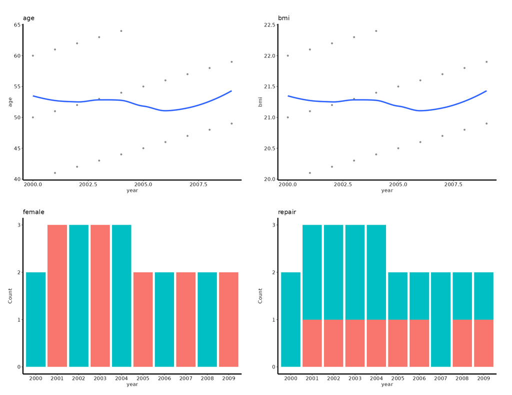

```r
# Embed while the PNG exists; study cleanup runs before HTML conversion.
knitr::asis_output(paste0(
  '<img src="', knitr::image_uri(png),
  '" alt="Postage stamp plots for the named subset">'
))
```

```r
stopifnot(identical(unname(tools::md5sum(legacy_files)),
                    unname(legacy_checksums)))
```

Open the Word file to compare row order, labels, counts, summaries, precision and footnotes with the legacy reference. Inspect each trend and postage figure for variable selection, axes and cohort. Record any methodological differences alongside the migration report before using the output in a study document.

### A job with no converter

Not every prefix has a migration adapter yet. `migrate_job()` still scaffolds the template, keeps every `EDIT:` marker for manual review, and its report says so plainly.

```r
distribution <- migrate_job(file.path(root, "distributions", "ac.age.sas"), "cohort", "eda")
distribution_report <- sub("[.]qmd$", "-migration.md", distribution)
cat(head(readLines(distribution_report), 6L), sep = "\n")
```

```
#> # Migration report
#>
#> Template: hvtiRtemplates 1.2.0 / ac
#>
#> **No converter: every choice is manual.** This template has no migration adapter yet;
#> the job is the plain scaffold and the evidence below is for porting by hand.
```